# Casos de COVID-19 para o Município de Uberaba

# Sumário executivo

## Gráfico das projeções

- Pontos pretos : número de casos confirmados a cada dia.
- Pontos laranjas: a previsão para os próximos 5 dias
- Cinza : intervalo de confiança dessa previsão.

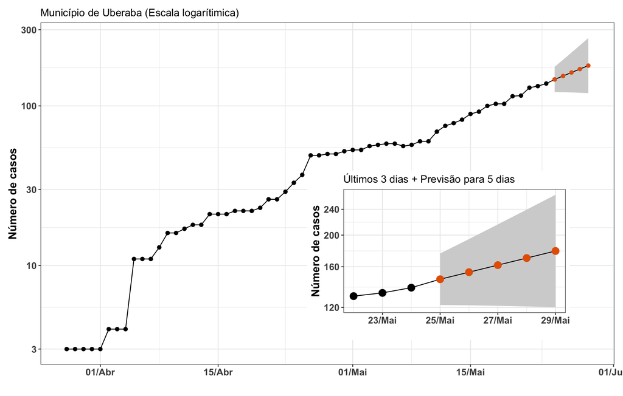

Estimativas de crescimento exponencial para os próximos 5 dias para o Município de Uberaba

# Detalhes técnicos

Na atual fase da epidemia o número diário de casos confirmados tem mostrado uma relação linear com o número de dias transcorridos, em escala logarítimica e para pequenos intervalos de tempo. Usamos essa relação observada empiricamente para ajustar uma regressão linear para contagens (glm Poisson) aos 5 últimos pontos da série temporal de casos notificados. Com este modelo de regressão projetamos os valores para os próximos 5 dias, e um intervalo de confiança da previsão.

## Limitações

**Os valores projetados serão válidos se a taxa de crescimento de casos confirmados for a mesma dos últimos 5 dias**

Este documento extrapola dados de número de casos notificados no estado até o dia de hoje. O número de casos notificados está atrasado com relação ao número real de casos, por conta dos tempos até surgimento de sintoma e realização do teste, e refletem provavelmente uma fração do total de casos, pois muitos casos leves provavelmente não são notificados. A propriedade das estimativas está para ser avaliada pelo grupo e métodos.

## Observatório COVID-19 BR

O Observatório Covid-19 BR é uma iniciativa independente, fruto da colaboração entre pesquisadores com o desejo de contribuir para a disseminação de informação de qualidade baseada em dados atualizados e análises cientificamente embasadas.

Criamos um sítio com códigos de fonte aberta que nos permite acompanhar o estado atual da epidemia de Covid-19 no Brasil, incluindo análises estatísticas e previsões. Modelos estatísticos e matemáticos para previsões da epidemia estão em preparação

**Site:** https://covid19br.github.io/index.html

**Contato:** obscovid19br@gmail.com